# ValidMind Python Library Introduction (for R users)

```python
import pandas as pd
```

## Initializing the ValidMind Library

After creating an account with ValidMind, we can find the project’s API key and secret in the settings page of the ValidMind dashboard:

[figure not shown]

The library credentials can be configured in two ways:

- By setting the `VM_API_KEY` and `VM_API_SECRET` environment variables or
- By passing `api_key` and `api_secret` arguments to the `init` function like this:

```python
vm.init(
    api_key='<your-api-key>',
    api_secret='<your-api-secret>',
    project="cl2r3k1ri000009jweny7ba1g"
)
```

The `project` argument is mandatory since it allows the library to associate all data collected with a specific account project.

```python
import validmind as vm

vm.init(
      api_host = "http://localhost:3000/api/v1/tracking",
      api_key = "e22b89a6b9c2a27da47cb0a09febc001",
      api_secret = "a61be901b5596e3c528d94231e4a3c504ef0bb803d16815f8dfd6857fac03e57",
      project = "clfmztk8t0000qvoo2wh30ex7"
)
```

```
True
```

### Using a demo dataset

For this simple demonstration, we will use the following bank customer churn dataset from Kaggle: https://www.kaggle.com/code/kmalit/bank-customer-churn-prediction/data.

We will train a sample model and demonstrate the following library functionalities:

- Logging information about a dataset
- Running data quality tests on a dataset
- Logging information about a model
- Logging training metrics for a model
- Running model evaluation tests

### Running a dataset evaluation test plan

We will now run a basic tabular dataset test plan that will compute and log the description, metrics and tests for the dataset. For now, ValidMind supports metrics and tests for a single dataset, so we first will combine the test and train sets into one to get complete datapoints.

```python
## load the train and test dataframes
# assume that the train and test datasets have been saved to disk as csv files
# see the r-customer-churn-model.ipynb notebook for details on how this can be done
df_train = pd.read_csv("r_demo/r_churn_train.csv")
df_test = pd.read_csv("r_demo/r_churn_test.csv")

vm_train_ds = vm.init_dataset(dataset=df_train, type="generic", target_column="Exited")
vm_test_ds = vm.init_dataset(dataset=df_test, type="generic", target_column="Exited")
```

```
Pandas dataset detected. Initializing VM Dataset instance...
Inferring dataset types...
Pandas dataset detected. Initializing VM Dataset instance...
Inferring dataset types...
```

```
Pandas dataset detected. Initializing VM Dataset instance...
Inferring dataset types...
```

Results for *tabular_dataset_description* Test Plan:

Logged the following dataset to the ValidMind platform:

|  | GeographyFrance | GeographyGermany | Gender | Age | Tenure | Balance | NumOfProducts | HasCrCard | IsActiveMember | EstimatedSalary | Exited |
| --- | --- | --- | --- | --- | --- | --- | --- | --- | --- | --- | --- |
| count | 8000.00000 | 8000.000000 | 8000.000000 | 8000.000000 | 8000.000000 | 8000.000000 | 8000.000000 | 8000.000000 | 8000.000000 | 8000.000000 | 8000.000000 |
| mean | 0.50125 | 0.251125 | 0.549500 | 38.948875 | 5.033875 | 76434.096511 | 1.532500 | 0.702625 | 0.519875 | 99790.187959 | 0.202000 |
| std | 0.50003 | 0.433687 | 0.497575 | 10.458952 | 2.885267 | 62612.251258 | 0.580505 | 0.457132 | 0.499636 | 57520.508892 | 0.401517 |
| min | 0.00000 | 0.000000 | 0.000000 | 18.000000 | 0.000000 | 0.000000 | 1.000000 | 0.000000 | 0.000000 | 11.580000 | 0.000000 |
| 25% | 0.00000 | 0.000000 | 0.000000 | 32.000000 | 3.000000 | 0.000000 | 1.000000 | 0.000000 | 0.000000 | 50857.102500 | 0.000000 |
| 50% | 1.00000 | 0.000000 | 1.000000 | 37.000000 | 5.000000 | 97263.675000 | 1.000000 | 1.000000 | 1.000000 | 99504.890000 | 0.000000 |
| 75% | 1.00000 | 1.000000 | 1.000000 | 44.000000 | 8.000000 | 128044.507500 | 2.000000 | 1.000000 | 1.000000 | 149216.320000 | 0.000000 |
| max | 1.00000 | 1.000000 | 1.000000 | 92.000000 | 10.000000 | 250898.090000 | 4.000000 | 1.000000 | 1.000000 | 199992.480000 | 1.000000 |

Logged the following dataset metric to the ValidMind platform:

Metric Name

dataset_correlations

Metric Type

dataset

Metric Scope

generic

Metric Plots Show All Plots

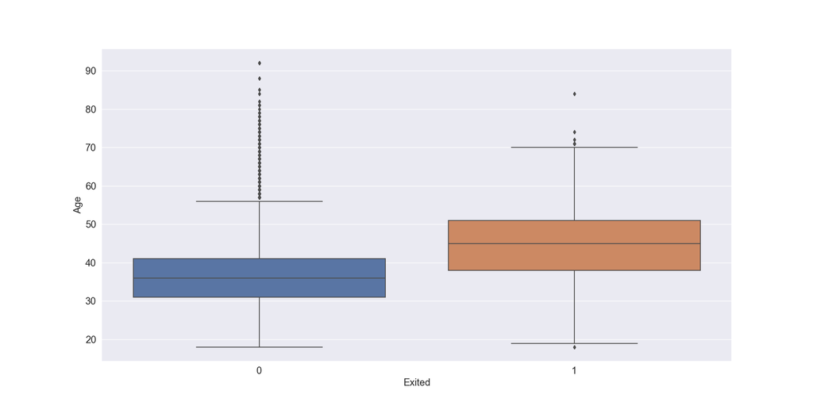

Results for *tabular_data_quality* Test Plan:

Logged the following test result to the ValidMind platform:

Class Imbalance ✅

See Result Details

Test Name

class_imbalance

Category

data_quality

Passed

True

Params

{'min_percent_threshold': 0.2}

Logged the following test result to the ValidMind platform:

Duplicates ✅

See Result Details

Test Name

duplicates

Category

data_quality

Passed

True

Params

{'min_threshold': 1}

Logged the following test result to the ValidMind platform:

Cardinality ✅

See Result Details

Test Name

cardinality

Category

data_quality

Passed

True

Params

{'num_threshold': 100, 'percent_threshold': 0.1, 'threshold_type': 'percent'}

Logged the following test result to the ValidMind platform:

Pearson Correlation ❌

See Result Details

Test Name

pearson_correlation

Category

data_quality

Passed

False

Params

{'max_threshold': 0.3}

Logged the following test result to the ValidMind platform:

Missing ✅

See Result Details

Test Name

missing

Category

data_quality

Passed

True

Params

{'min_threshold': 1}

Logged the following test result to the ValidMind platform:

Skewness ❌

See Result Details

Test Name

skewness

Category

data_quality

Passed

False

Params

{'max_threshold': 1}

Logged the following test result to the ValidMind platform:

Unique ❌

See Result Details

Test Name

unique

Category

data_quality

Passed

False

Params

{'min_percent_threshold': 1}

Logged the following test result to the ValidMind platform:

Zeros ❌

See Result Details

Test Name

zeros

Category

data_quality

Passed

False

Params

{'max_percent_threshold': 0.03}

```python
# run dataset tests on df_train and df_test combined
vm_dataset_combined = vm.init_dataset(
    dataset=pd.concat([df_train, df_test]),
    type="generic",
    target_column="Exited",
)
vm.run_test_plan("tabular_dataset", dataset=vm_dataset_combined)
```

### Running a model evaluation test plan for our LogisticRegression R model

We will now run a basic model evaluation test plan that is compatible with the R model we will be loading.

```python
## load the model
# assume that the model has been saved to disk as a serialized R object (.rds)
# see the r-customer-churn-model.ipynb notebook for details on how this can be done
# model_type must be passed for R models:
# Currently, LogisticRegression, LinearRegression (glm and lm in R) XGBClassifier and XGBRegressor are supported
vm_model = vm.init_r_model("r_demo/r_log_reg_churn_model.rds", model_type="LogisticRegression")
```

Results for *sklearn_classifier_metrics* Test Plan:

Logged the following model to the ValidMind platform:

Framework

Architecture

Task

classification

Subtask

binary

Logged the following evaluation metric to the ValidMind platform:

Metric Name

accuracy

Metric Type

evaluation

Metric Scope

test

Metric Value

```
0.8604166666666667
```

Logged the following evaluation metric to the ValidMind platform:

Metric Name

confusion_matrix

Metric Type

evaluation

Metric Scope

test

Metric Plots

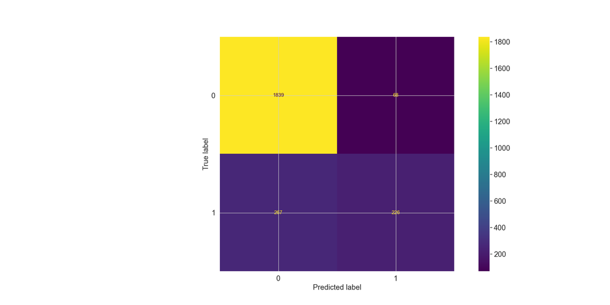

Logged the following evaluation metric to the ValidMind platform:

Metric Name

f1_score

Metric Type

evaluation

Metric Scope

test

Metric Value

```
0.5743329097839899
```

Logged the following training metric to the ValidMind platform:

Metric Name

pfi

Metric Type

training

Metric Scope

training_dataset

Metric Plots

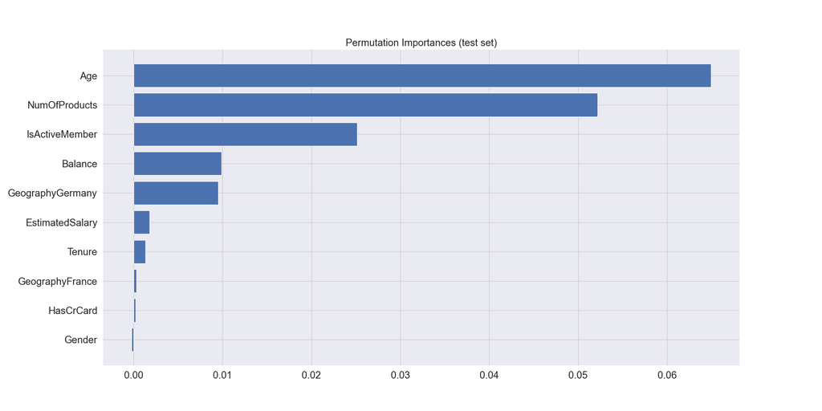

Logged the following evaluation metric to the ValidMind platform:

Metric Name

pr_curve

Metric Type

evaluation

Metric Scope

test

Metric Plots

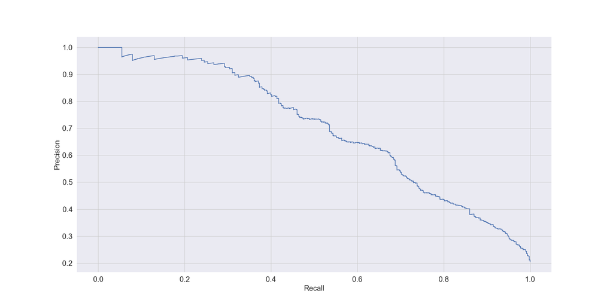

Logged the following evaluation metric to the ValidMind platform:

Metric Name

precision

Metric Type

evaluation

Metric Scope

test

Metric Value

```
0.7687074829931972
```

Logged the following evaluation metric to the ValidMind platform:

Metric Name

recall

Metric Type

evaluation

Metric Scope

test

Metric Value

```
0.45841784989858014
```

Logged the following evaluation metric to the ValidMind platform:

Metric Name

roc_auc

Metric Type

evaluation

Metric Scope

test

Metric Value

```
0.7113798740840568
```

Logged the following evaluation metric to the ValidMind platform:

Metric Name

roc_curve

Metric Type

evaluation

Metric Scope

test

Metric Plots

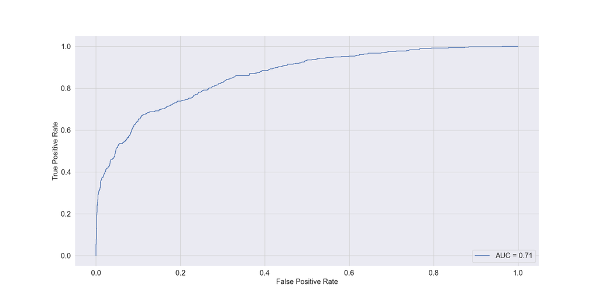

Logged the following training metric to the ValidMind platform:

Metric Name

csi

Metric Type

training

Metric Scope

training:validation

Metric Value

```
{'GeographyFrance': 2e-06, 'GeographyGermany': 5e-05, 'Gender': 7e-06, 'Age': 0.000446, 'Tenure': 0.000397, 'Balance': 0.001007, 'NumOfProducts': 0.000273, 'HasCrCard': 0.000234, 'IsActiveMember': 4.2e-05, 'EstimatedSalary': 0.000501}
```

Logged the following training metric to the ValidMind platform:

Metric Name

psi

Metric Type

training

Metric Scope

training:validation

Metric Value

```
     initial  percent_initial   new  percent_new       psi
bin
1       2840          0.50714  1218     0.507500  0.000000
2       1155          0.20625   474     0.197500  0.000379
3        464          0.08286   218     0.090833  0.000733
4        301          0.05375   126     0.052500  0.000029
5        172          0.03071    72     0.030000  0.000017
6        174          0.03107    73     0.030417  0.000014
7        116          0.02071    57     0.023750  0.000415
8        121          0.02161    54     0.022500  0.000036
9        152          0.02714    67     0.027917  0.000022
10       105          0.01875    41     0.017083  0.000155
```

Logged the following plots to the ValidMind platform:

Metric Plots

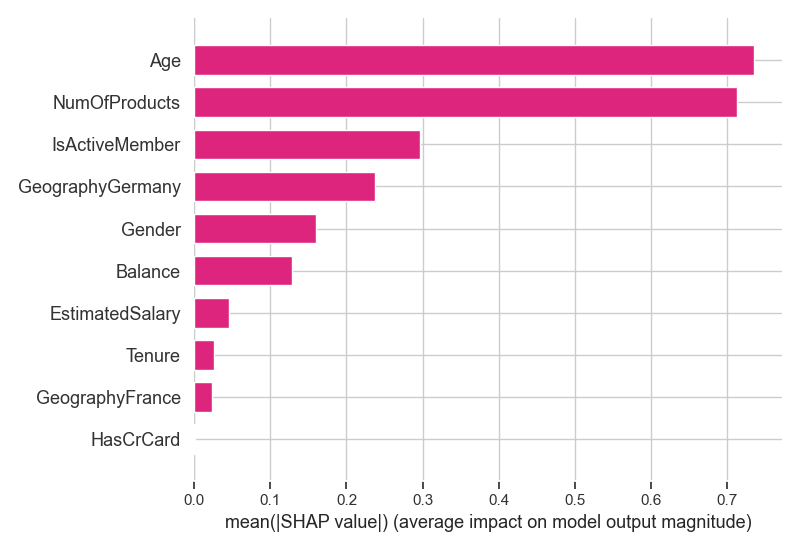

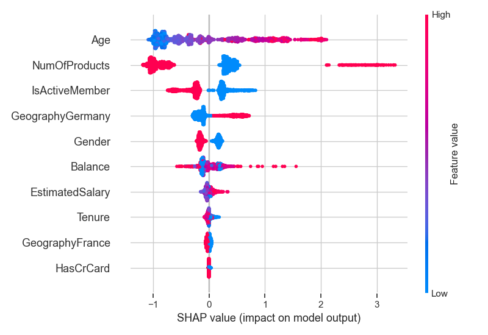

```python
vm.run_test_plan("sklearn_classifier", model=vm_model, train_ds=vm_train_ds, test_ds=vm_test_ds)
```

Results for *sklearn_classifier_validation* Test Plan:

Logged the following test result to the ValidMind platform:

Accuracy Score ✅

See Result Details

Test Name

accuracy_score

Category

model_performance

Passed

True

Params

{'min_threshold': 0.7}

Logged the following test result to the ValidMind platform:

F1 Score ❌

See Result Details

Test Name

f1_score

Category

model_performance

Passed

False

Params

{'min_threshold': 0.5}

Logged the following test result to the ValidMind platform:

Roc Auc Score ❌

See Result Details

Test Name

roc_auc_score

Category

model_performance

Passed

False

Params

{'min_threshold': 0.5}

Logged the following test result to the ValidMind platform:

Training Test Degradation ❌

See Result Details

Test Name

training_test_degradation

Category

model_performance

Passed

False

Params

{'metrics': ['accuracy', 'precision', 'recall', 'f1']}

### Running a model evaluation test plan for our XGBoost R model

We will now run a basic model evaluation test plan that is compatible with the R model we will be loading.

```python
## load the model
# assume that the model has been saved to disk as an XGBoost .bin or .json model
# see the r-customer-churn-model.ipynb notebook for details on how this can be done
vm_model = vm.init_r_model("r_demo/r_xgb_churn_model.json", model_type="XGBClassifier")
```

Results for *sklearn_classifier_metrics* Test Plan:

Logged the following model to the ValidMind platform:

XGBClassifier (main) 📦

Framework

XGBoost (v1.7.4)

Architecture

Extreme Gradient Boosting

Task

classification

Subtask

binary

Logged the following evaluation metric to the ValidMind platform:

Metric Name

accuracy

Metric Type

evaluation

Metric Scope

test

Metric Value

```
0.8604166666666667
```

Logged the following evaluation metric to the ValidMind platform:

Metric Name

confusion_matrix

Metric Type

evaluation

Metric Scope

test

Metric Plots

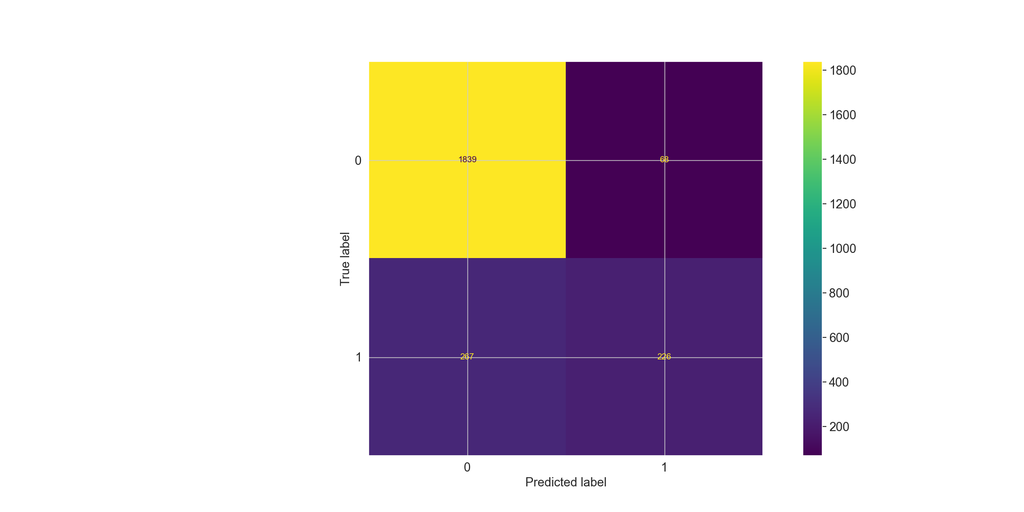

Logged the following evaluation metric to the ValidMind platform:

Metric Name

f1_score

Metric Type

evaluation

Metric Scope

test

Metric Value

```
0.5743329097839899
```

Logged the following training metric to the ValidMind platform:

Metric Name

pfi

Metric Type

training

Metric Scope

training_dataset

Metric Plots

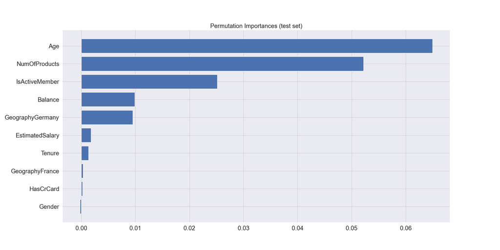

Logged the following evaluation metric to the ValidMind platform:

Metric Name

pr_curve

Metric Type

evaluation

Metric Scope

test

Metric Plots

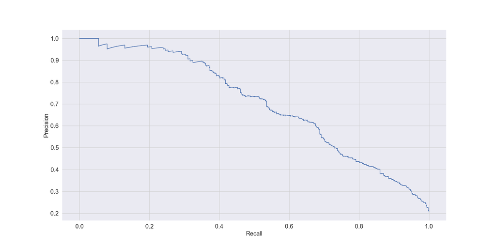

Logged the following evaluation metric to the ValidMind platform:

Metric Name

precision

Metric Type

evaluation

Metric Scope

test

Metric Value

```
0.7687074829931972
```

Logged the following evaluation metric to the ValidMind platform:

Metric Name

recall

Metric Type

evaluation

Metric Scope

test

Metric Value

```
0.45841784989858014
```

Logged the following evaluation metric to the ValidMind platform:

Metric Name

roc_auc

Metric Type

evaluation

Metric Scope

test

Metric Value

```
0.7113798740840568
```

Logged the following evaluation metric to the ValidMind platform:

Metric Name

roc_curve

Metric Type

evaluation

Metric Scope

test

Metric Plots

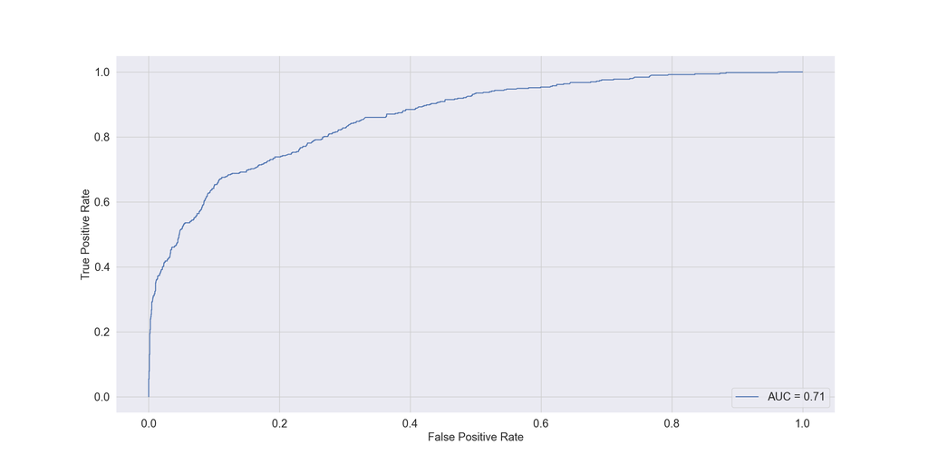

Logged the following training metric to the ValidMind platform:

Metric Name

csi

Metric Type

training

Metric Scope

training:validation

Metric Value

```
{'GeographyFrance': 2.2675834122647982e-06, 'GeographyGermany': 4.980609560297461e-05, 'Gender': 6.616065980252932e-06, 'Age': 0.0004455484363232503, 'Tenure': 0.0003965145869141729, 'Balance': 0.001006505120262602, 'NumOfProducts': 0.00027307377283343113, 'HasCrCard': 0.0002340104482860316, 'IsActi…
```

Logged the following training metric to the ValidMind platform:

Metric Name

psi

Metric Type

training

Metric Scope

training:validation

Metric Value

```
     initial  percent_initial   new  percent_new           psi
bin
1       2840         0.507143  1218     0.507500  2.514205e-07
2       1155         0.206250   474     0.197500  3.793164e-04
3        464         0.082857   218     0.090833  7.330787e-04
4        301         0.053750   126     0.052500  2.941312e-05
5        172         0.030714    72     0.030000  1.680750e-05
6        174         0.031071    73     0.030417  1.394512e-05
7        116         0.020714    57     0.023750  4.151611e-04
8        121         0.021607    54     0.022500  3.615300e-05
9        152         0.027143    67     0.027917  2.175175e-05
10       105         0.018750    41     0.017083  1.551507e-04
```

Logged the following plots to the ValidMind platform:

Metric Plots

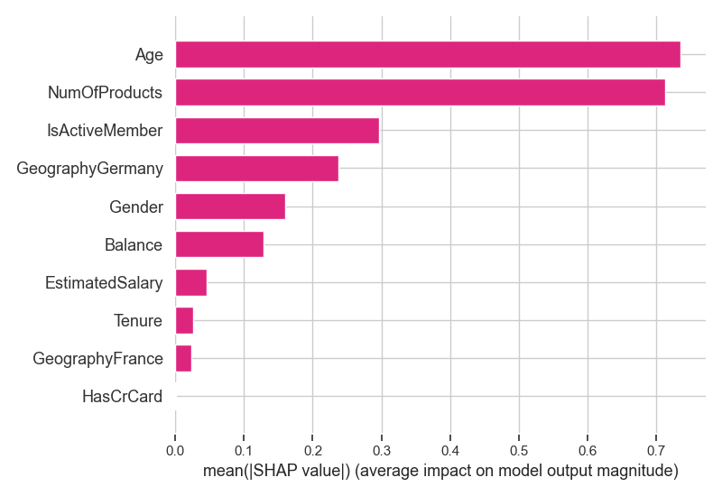

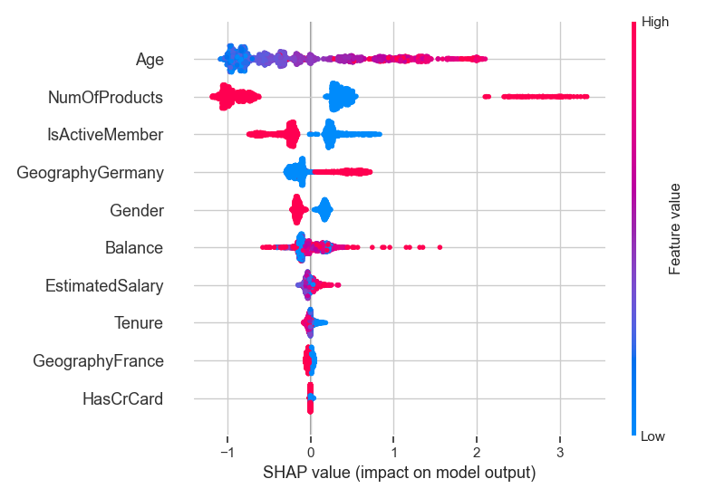

```python
# send=False here to not overwrite the results from the LogisticRegression model. In practice, this would be under
# a different VM Project ID
vm.run_test_plan("sklearn_classifier", model=vm_model, train_ds=vm_train_ds, test_ds=vm_test_ds, send=False)
```

Results for *sklearn_classifier_validation* Test Plan:

Logged the following test result to the ValidMind platform:

Accuracy Score ✅

See Result Details

Test Name

accuracy_score

Category

model_performance

Passed

True

Params

{'min_threshold': 0.7}

Logged the following test result to the ValidMind platform:

F1 Score ❌

See Result Details

Test Name

f1_score

Category

model_performance

Passed

False

Params

{'min_threshold': 0.5}

Logged the following test result to the ValidMind platform:

Roc Auc Score ❌

See Result Details

Test Name

roc_auc_score

Category

model_performance

Passed

False

Params

{'min_threshold': 0.5}

Logged the following test result to the ValidMind platform:

Training Test Degradation ❌

See Result Details

Test Name

training_test_degradation

Category

model_performance

Passed

False

Params

{'metrics': ['accuracy', 'precision', 'recall', 'f1']}